# Red wine (Vinho Verde) quality exploration by Sebastien LOPATOWSKI

# Multivariate Analysis

### Talk about some of the relationships you observed in this part of the investigation. Were there features that strengthened each other in terms of looking at your feature(s) of interest?

The residual sugar with few chlorides give a good quality of wine. Moreover, the volatile.acidity (less than 0.8) give also a good wine quality.

### OPTIONAL: Did you create any models with your dataset? Discuss the strengths and limitations of your model.

# Final Plots and Summary

### Plot One

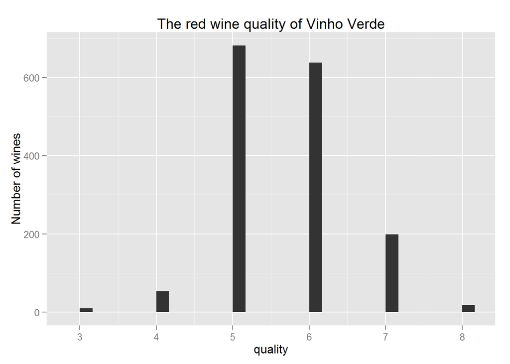

### Description One

The red wine quality of Vinho Verde is quite correct. The most number of wines is around 5, 6 and 7.

### Plot Two

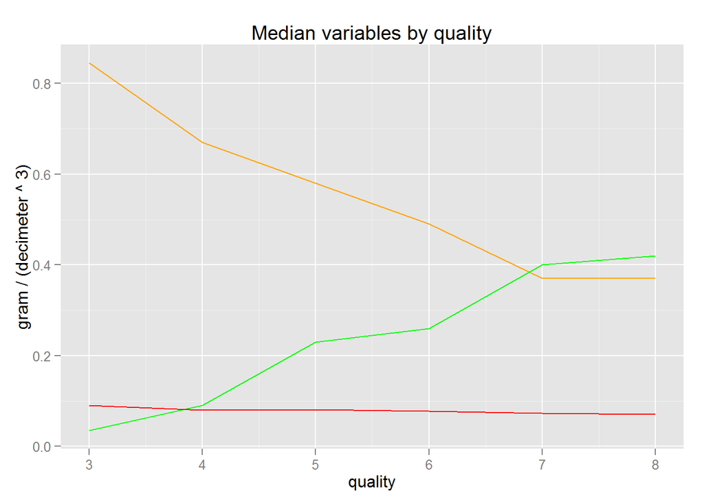

### Plot Three

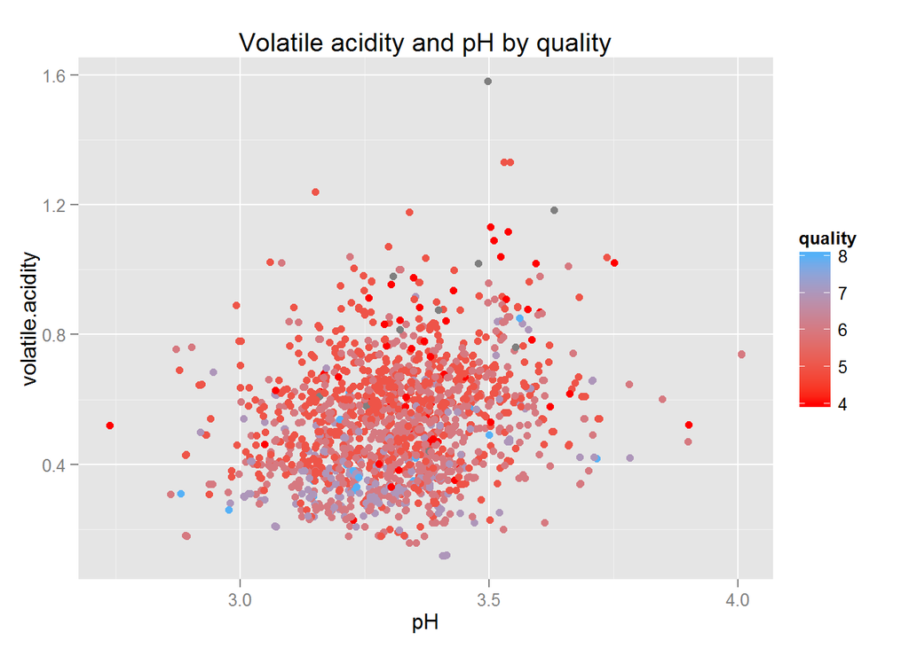

### Description Three

To have a good quality of wine the volatile acidity must be low (less than 0.6) with the pH between 3 to 3.5.

# Reflection